# FigureYa180FGAplotV2

# Academic Citation

If you use this code in your work or research, we kindly request that you cite our publication:

Xiaofan Lu, et al. (2025). FigureYa: A Standardized Visualization Framework for Enhancing Biomedical Data Interpretation and Research Efficiency. iMetaMed. https://doi.org/10.1002/imm3.70005

# 需求描述

# Requirement

cBioPortal上的Fraction Genome Altered的算法 The Fraction Genome Altered algorithm on cBioPortal https://groups.google.com/forum/#!topic/cbioportal/4DvUVuRgrTw

[figure not shown]

出自https://www.cbioportal.org/study/summary?id=kirc_tcga_pan_can_atlas_2018 fromhttps://www.cbioportal.org/study/summary?id=kirc_tcga_pan_can_atlas_2018

另外一篇文章用了Fraction Genome Altered的概念，但算法跟cBioPortal但不同。 Another article used the concept of Fraction Genome Altered, but the algorithm was different from that of cBioPortal.

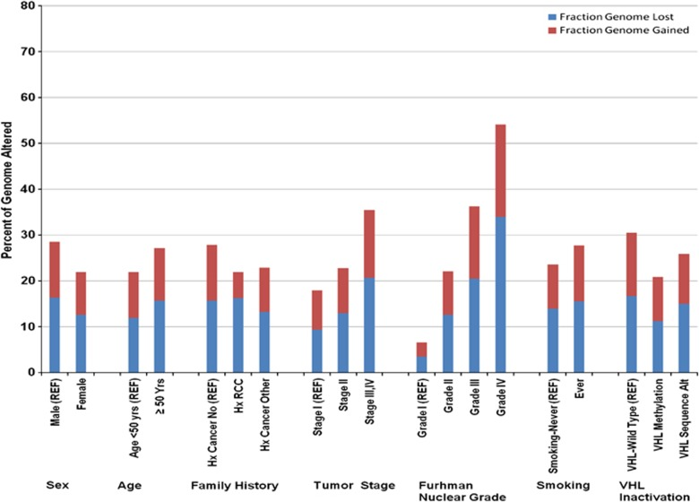

出自https://www.nature.com/articles/oncsis201214 fromhttps://www.nature.com/articles/oncsis201214

Figure 1. Fraction (%) of the FGL, FGG and FGA among ccRCC case subgroups. P-values between subgroups were as follows: males vs females (P=0.002), age (<50, vs ⩾50 years, P=0.06), any family history of cancer (P=0.02), stage (P<0.00001), grade (P<0.0001), ever vs never smoking (P=0.05), VHL wild-type cases vs those with VHL promoter hypermethylation (P=0.03), VHL wild-type cases vs those with VHL sequence alterations (P=0.17). REF, referent group.

cBioPortal提供的Fraction Genome Altered算的是总体的，没有区分gain和lost，想用cBioPortal的算法分别计算fraction of genome gained (FGG) 和fraction of the genome lost (FGL)，并使用临床信息比较各个分组间的差异。输入TCGA的CNV数据，计算FGA、FGG、FGL，复现文章的图。 The Fraction Genome Altered provided by cBioPortal is overall and does not distinguish between gain and lost. the algorithm of cBioPortal was intended to calculate fraction of genome gained (FGG) and fraction of the genome lost (FGL) respectively, and clinical information was used to compare the differences among the groups. Input the CNV data of TCGA, calculate FGA, FGG, and FGL, and reproduce the figures of the article.

# 应用场景

# Application Scenarios

自己的测序数据，用cBioPortal的算法计算Fraction Genome Altered (FGA)。 Our own sequencing data were used to calculate Fraction Genome Altered (FGA) using the algorithm of cBioPortal.

或者使用TCGA的数据，计算不同临床分组的FGA、FGG和FGL，并进行差异检验。 Alternatively, the data from TCGA can be used to calculate the FGA, FGG and FGL of different clinical groups and conduct difference tests.

# 环境设置

# Environment Setup

```r
source("install_dependencies.R")
```

```
## Starting R package installation...
## ===========================================
##
## Installing CRAN packages...
## Package already installed: Cairo
## Package already installed: Rmisc
## Package already installed: ggplot2
## Package already installed: magrittr
## Package already installed: patchwork
## Package already installed: stringr
##
## ===========================================
## Package installation completed!
## You can now run your R scripts in this directory.
```

```r
library(ggplot2)
library(magrittr)
library(patchwork)
library(Rmisc)
library(Cairo)
library(stringr)

Sys.setenv(LANGUAGE = "en") #显示英文报错信息  # Display an English error message
options(stringsAsFactors = FALSE) #禁止chr转成factor  # prohibit chr from being converted to factor
```

自定义函数计算mean、se和p值 Custom functions calculate mean, se and p values

```r
cal_ms <- function(x,y){
  table1=data.frame()
  for (i in y) {
    name=summarySE(x,measurevar=c(colnames(x)[ncol(x)]), groupvars=c(colnames(x)[i]))[[1]]
    mean=summarySE(x, measurevar=c(colnames(x)[ncol(x)]), groupvars=c(colnames(x)[i]))[[3]] #mean
    se=summarySE(x, measurevar=c(colnames(x)[ncol(x)]), groupvars=c(colnames(x)[i]))[[5]] #se

    table=data.frame(group=rep(colnames(x)[i],length(mean)),subgroup=name,mean=mean,se=se)
    table1=rbind(table1,table)

  }
  table1$subgroup=factor(table1$subgroup,levels=unique(table1$subgroup))
  table1$group=factor(table1$group,levels=unique(table1$group))
  return(table1)
}#计算mean和se,排序  # Calculate mean and se, sort
cal_p=function(x,y){
  table2=data.frame()
  for (i in y) {
    m<-aov(x[,ncol(x)]~as.factor(x[,i]))
    summary(m)
    table=cbind(rep(colnames(x)[i],nrow((TukeyHSD(m))[[1]])),(TukeyHSD(m))[[1]])
    table2=rbind(table2,table)
  }
  return(table2)
}#计算p值  # Calculate the p value
signif=function(table1,table2){
  signif1=c()
  for (i in 1:length(table(table2[,1]))) {
    signif1=c(signif1,"Ref",table2[table2[,1]==levels(table1[,1])[i],5][1:length(table1[table1[,1]==names(table(table2[,1])[i]),"subgroup"])-1])
  }#提取p值  # Extract the P-value
  for (i in 1:length(signif1)) {
    if (!is.na(as.numeric(signif1[i]))) {
      signif1[i]=ifelse(signif1[i]>0.05,"",ifelse(signif1[i]<=0.0001,"****",ifelse(signif1[i]<=0.001,"***",ifelse(signif1[i]<=0.01,"**",ifelse(signif1[i]<=0.05,'*')))))
    }
  }#转换标记  # Conversion Markup
  return(signif1)
}#准备显著性标记的数据  # Prepare the data for salient marking
mar=function(tableGL){
  mar=round(max(tableGL[,"mean"]+tableGL[,"se"]),1)+0.05
  return(mar)
}#ggplot坐标长度  #ggplot coordinate length
```

# 输入文件

# Input File

从Xena获取TCGA_KIRC的cnv数据、clinical数据。 Obtain the cnv data and clinical data of TCGA_KIRC from Xena.

数据来源：Data source: https://xenabrowser.net/datapages/?cohort=TCGA%20Kidney%20Clear%20Cell%20Carcinoma%20(KIRC)&removeHub=https%3A%2F%2Fxena.treehouse.gi.ucsc.edu%3A443

```r
# 加载Xena上TCGA_KIRC的nocnv数据
# Load the nocnv data of TCGA_KIRC on Xena
Segment <- read.delim("SNP6_nocnv_genomicSegment.gz")
# 加载Xena上TCGA_KIRC的临床数据
# Load the clinical data of TCGA_KIRC on Xena
KIRC <- read.delim("KIRC_clinicalMatrix")
```

再导入cBioPortal上FGA的数据，用于验证算法的结果。 Then import the FGA data from cBioPortal to verify the results of the algorithm.

数据来源：Data source: https://www.cbioportal.org/study/summary?id=kirc_tcga_pan_can_atlas_2018

```r
# 单独导入VHL突变数据(来自cBioPortal)
# Import VHL mutation data separately (from cBioPortal)
VHL <- read.delim("PATIENT_DATA_oncoprint.tsv", header=FALSE, stringsAsFactors=FALSE)
# 导入cBioPortal上KIRC的数据
# Import KIRC data from cBioPortal
cBio <- read.delim("kirc_tcga_pan_can_atlas_2018_clinical_data.tsv", stringsAsFactors=FALSE)
head(Segment) #注意最后一列的value值的单位是log2(copy number/2)   # Note that the unit of the value in the last column is log2(copy number/2)
```

```
##            sample  chr    start      end   value
## 1 TCGA-B8-A54K-01 chr1  3218610  9489406  0.0100
## 2 TCGA-B8-A54K-01 chr1  9489972  9494466 -1.8578
## 3 TCGA-B8-A54K-01 chr1  9498113 16405611  0.0193
## 4 TCGA-B8-A54K-01 chr1 16407320 16408804 -1.7357
## 5 TCGA-B8-A54K-01 chr1 16413265 29192399  0.0101
## 6 TCGA-B8-A54K-01 chr1 29194818 29194901  1.8713
```

# 计算Fraction Genome Altered (FGA)

# Calculate Fraction Genome Altered (FGA)

先贴上计算公式便于理解： First, attach the calculation formula for easier understanding:

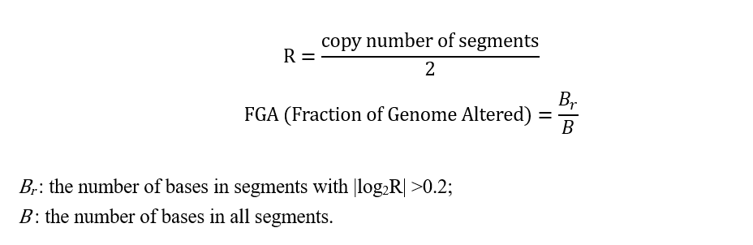

因此，Segment中的value值即是log2R。如果是自己的测序数据则要注意是否是log2R，还是copy number（见文末的注意事项）。 Therefore, the value in the Segment is log2R. If it is your own sequencing data, pay attention to whether it is log2R or copy number (see the precautions at the end of the text).

## 数据清洗

## Data cleaning

```r
Segment$bases=Segment$end-Segment$start
Segment$sample%<>%str_sub(end=-4)
VHL=t(VHL)
colnames(VHL)=VHL[2,]
VHL=VHL[-1:-2,]
VHL=cbind(VHL,'VHL'=c(rep('Mut',175),rep('Wild',nrow(VHL)-175)))
VHL=as.data.frame(VHL)
VHL=VHL[,c(1,8)]
colnames(VHL)[1]='Patient'
clinical=KIRC[,c(1,19,38,64,55)]
clinical$sampleID%<>%str_sub(end=-4)
clinical%<>%unique.data.frame()
colnames(clinical)=c('Patient','Age','Gender','Stage','Grade')
clinical$Age=ifelse(clinical$Age>=65,'Older','Younger')
clinical=clinical[!clinical$Stage=='[Discrepancy]',]
clinical=clinical[!(clinical$Grade==''|clinical$Grade=='GX'),]
mer=merge(clinical,VHL,all=FALSE)
```

## 计算FGA、FGG和FGL

## Calculate FGA, FGG and FGL

```r
data=data.frame()

for (i in 1:length(table(Segment$sample))) {
  tmp=Segment[Segment$sample==names(table(Segment$sample))[i],]
  if (length(tmp[abs(tmp$value)>0.2,"bases"][6])==0) {
    FGA=0
  } else {
    FGA=sum(tmp[abs(tmp$value)>0.2,"bases"])/sum(tmp[,"bases"])
  }

  if (length(tmp[tmp$value>0.2,"bases"][6])==0) {
    FGG=0
  } else {
    FGG=sum(tmp[tmp$value>0.2,"bases"])/sum(tmp[,"bases"])
  }

  if (length(tmp[tmp$value<(-0.2),"bases"][6])==0) {
    FGL=0
  } else {
    FGL=sum(tmp[tmp$value<(-0.2),"bases"])/sum(tmp[,"bases"])
  }

  tmp=data.frame(Patient=names(table(Segment$sample))[i],FGA=FGA,FGG=FGG,FGL=FGL)
  data=rbind(data,tmp)
}
```

## 合并数据、导出数据

## Merge data, export data

```r
All=merge(mer,data,all=FALSE)
save(All,file='all_data.Rdata')
write.csv(All,file = 'KIRC_FGA.csv',row.names = F)
```

# 对比cBioPortal上的FGA数据

# Compare the FGA data on cBioPortal

```r
cBio_FGA=cBio[,c(2,22)]
colnames(cBio_FGA)=c('Patient','FGA_cBio')
cBio_FGA=cBio_FGA[!is.na(cBio_FGA$FGA_cBio),]
COMPARE=merge(cBio_FGA,All[,c(1,7)],all=FALSE)
COMPARE$FGA%<>%round(4)
table(COMPARE$FGA==COMPARE$FGA_cBio)
```

```
##
## FALSE  TRUE
##    29   467
```

```r
# 查看不一致的样本
# View inconsistent samples
head(COMPARE[!COMPARE$FGA==COMPARE$FGA_cBio,])
```

```
##         Patient FGA_cBio    FGA
## 5  TCGA-A3-3308   0.0844 0.0885
## 6  TCGA-A3-3311   0.0883 0.1110
## 7  TCGA-A3-3313   0.2078 0.1827
## 9  TCGA-A3-3317   0.2776 0.2777
## 10 TCGA-A3-3319   0.3654 0.3652
## 11 TCGA-A3-3320   0.1083 0.1085
```

结论：大部分数据是一致的，个别样本不同考虑是采用的cnv文件的不同（见文末的注意事项）。 Conclusion: The majority of the data are consistent. The differences in individual samples are due to the different cnv files used (see the notes at the end of the text).

# 复现文献的Figure

# Reproduce the Figure of the literature

计算mean和se和p值并画图，这里用的检验方法是AONVA，并使用TukeyHSD进行组间比较（结果只取reference组和其他组的显著性以便于显示）。 Calculate the mean, se and p values and draw graphs. The test method used here is AONVA, and TukeyHSD is used for inter-group comparison (the results only take the significance of the reference group and other groups for easy display).

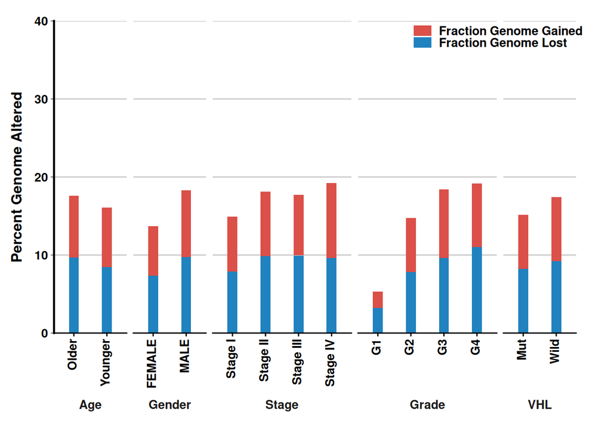

```r
table1=cal_ms(All[,c(1:6,7)],2:6) #(保持最后一列是目标变量) #(Keep the last column as the target variable)
table2=cal_p(All[,c(1:6,7)],2:6)#(保持最后一列是目标变量) #(Keep the last column as the target variable)
signif1=signif(table1,table2)
table3=cal_ms(All[,c(1:6,9)],2:6) #FGL
table4=cal_p(All[,c(1:6,9)],2:6)  #FGL
signif2=signif(table3,table4) #FGL
table5=cal_ms(All[,c(1:6,8)],2:6) #FGG
table6=cal_p(All[,c(1:6,8)],2:6)  #FGG
signif3=signif(table5,table6) #FGG
tableGL=rbind(cbind(table3,class=rep('FGL',nrow(table3))),cbind(table5,class=rep('FGG',nrow(table5)))) #合并FGL、FGG  # Merge FGL and FGG

#画图
# Drawing
s=10 #统一字体大小  # Uniform font size
orinpl <- ggplot(tableGL, aes(x = subgroup,
                       y = mean,fill=class))+
  geom_bar(stat = 'identity',position="stack",width = 0.3) +
  scale_x_discrete(name="")+
  theme_classic()+
  theme(axis.line.y =element_line(size=0.8),
        axis.text.y =element_text(face='bold',size=s),
        axis.title.y = element_text(face='bold',size=s+2,vjust = 3),
        axis.ticks.y =element_line(size=0.2),
        axis.text.x = element_text(angle=90,hjust =1,vjust = 0.3,face='bold',size=s),
        legend.position = c(0.85,0.95),
        legend.key.height =  unit(0.1, "inch"),
        legend.key.width  =  unit(0.22, "inch"),
        legend.text = element_text(face='bold',size=s),
        legend.background = element_blank(),
        panel.grid.major.y = element_line(size=0.5,colour = 'grey80'),
        plot.margin = unit(c(1.2, 2, 0.3, 1), "lines"),
        legend.title=element_blank())+

  scale_fill_manual(values  = c("#db5049","#2082be"),breaks=c("FGG","FGL"),
                    labels=c("Fraction Genome Gained","Fraction Genome Lost"))+
  scale_y_continuous(limits = c(0,0.4),breaks =seq(0,0.8,0.1),
                     labels=seq(0,0.8,0.1)*100,expand = c(0,0),
                     name  = "Percent Genome Altered")+
  facet_grid(cols = vars(group),scales = "free_x",space = "free_x",switch = "x")+theme(
    strip.text.x = element_text(size = s, face = "bold",vjust = 0),
    strip.background = element_blank(),
    strip.placement = "outside")
orinpl
```

```r
#ggsave(file='FGA.png',orinpl,height = 6,width=9,units = c("in"),dpi = 1200)
ggsave(file='FGA.pdf',orinpl,height = 6,width=9,units = c("in"))
```

# 自定义进阶版FGA图

# Custom advanced FGA map

文献中的Figure 1 没有标注p值和se，所以画个自定义进阶版的FGA图。 The P-value and se are not marked in Figure 1 of the literature, so a custom advanced version of the FGA diagram is drawn.

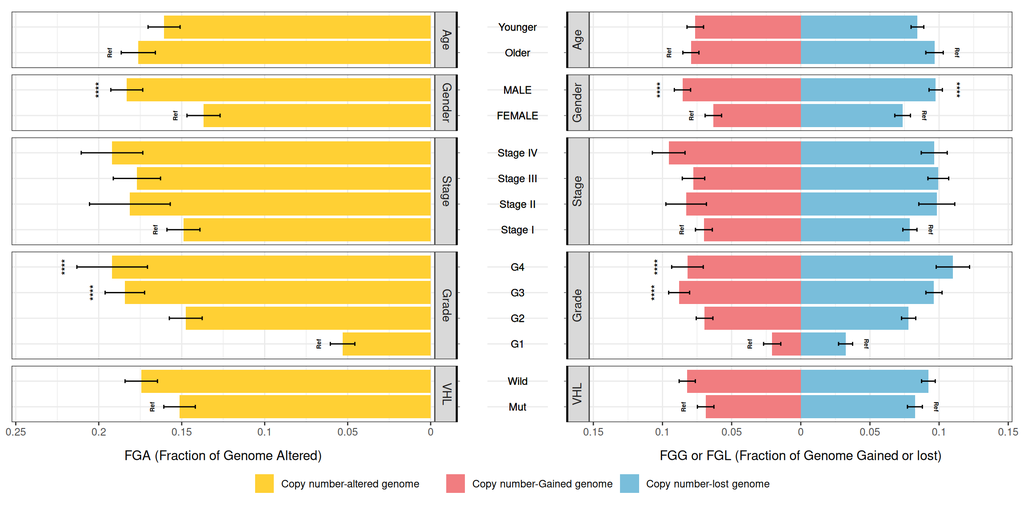

```r
gap=0.05 #图纵坐标间隔 # Vertical coordinate interval of the graph

# 左侧部分(FGA)
# Left Part (FGA)
if (T) {
p1=ggplot(table1, aes(x = subgroup,
                      y = -mean,fill=rep("0",nrow(table1))))+
  geom_bar(stat = 'identity') +
  geom_errorbar(aes(ymax = -mean -se, ymin = -mean+se),position = position_dodge(0.9), width = 0.15)+
  scale_x_discrete(name="",position = "top")+
  geom_text(aes(y = -mean-se-0.007, label = signif1),position = position_dodge(0.9), size = ifelse(signif1=='Ref',1.8,3), fontface = "bold",angle=90)+
  theme_bw()+
  theme(axis.line.y =element_line(size=0.8),
        axis.ticks.y =element_line(size=0.2),
        axis.text.y = element_blank(),
        axis.title.x = element_text(vjust = -2),
        plot.margin = unit(c(0.3, -1.7, 0.3, 0.3), "lines"),
        legend.title=element_blank())+
  coord_flip()+
  scale_fill_manual(values  = c("#FFD034"),breaks=c("0"),labels=c("Copy number-altered genome"))+
  scale_y_continuous(limits = c(-mar(table1),0),
                     breaks =seq(-0.5,0,gap),labels=abs(seq(-0.5,0,gap)),expand = c(0.01,0),
                     name  = "FGA (Fraction of Genome Altered)",position = "left")

p3=p1 +
  facet_grid(rows = vars(group),scales = "free_y",space = "free_y")+
  theme(strip.text.y = element_text(size = 10, angle= -90,vjust =1))
}#画图  # Drawing
#p3

# 右侧部分(FGG/FGL)
# Right Part (FGG/FGL)
if (T) {

p2 <- ggplot(tableGL, aes(x = subgroup,
                      y = ifelse(class=='FGG',-mean,mean),fill=class))+
  geom_bar(stat = 'identity') +
  geom_errorbar(data=tableGL[tableGL$class=='FGL',],aes(ymax = mean+se, ymin =mean-se),position = position_dodge(0.9), width = 0.15)+
  geom_errorbar(data=tableGL[tableGL$class=='FGG',],aes(ymax = -mean-se, ymin =-mean+se),position = position_dodge(0.9), width = 0.15)+
  geom_text(data=tableGL[tableGL$class=='FGG',],aes(y = -mean -se-0.01, label = signif2),position = position_dodge(0.9), size = ifelse(signif2=='Ref',1.8,3), fontface = "bold",angle=90)+
  geom_text(data=tableGL[tableGL$class=='FGL',],aes(y = mean+se+0.01, label = signif3),position = position_dodge(0.9), size = ifelse(signif3=='Ref',1.8,3), fontface = "bold",angle=-90)+
  scale_x_discrete(name="")+
  theme_bw()+
  theme(axis.line.y =element_line(size=0.8),
        axis.ticks.y =element_line(size=0.2),
        axis.text.y = element_blank(),
        axis.title.x = element_text(vjust = -2),
        plot.margin = unit(c(0.3, 0.3, 0.3, -1), "lines"),
        legend.title=element_blank())+
  coord_flip()+
  scale_fill_manual(values  = c("#f17d80","#79BEDB"),breaks=c("FGG","FGL"),
                    labels=c("Copy number-Gained genome","Copy number-lost genome"))+
  scale_y_continuous(limits = c(-mar(tableGL[tableGL$class=='FGG',]),mar(tableGL[tableGL$class=='FGL',])),breaks =seq(-0.5,0.5,gap),
                     labels=abs(seq(-0.5,0.5,gap)),expand = c(0.01,0),
                     name  = "FGG or FGL (Fraction of Genome Gained or lost)")


p4 <- p2+
  facet_grid(rows = vars(group),scales = "free_y",space = "free_y",switch = "y")+
  theme(strip.text.y = element_text(size = 10, angle= -90,vjust = 1))

}
#p4

# 中间部分
# Middle Part
pp=ggplot()+
geom_text(data = tableGL,
          aes(label = subgroup, x=subgroup), y = 0.5,
          size = 0.8*11/.pt, # match font size to theme
          hjust = 0.5, vjust = 0.5)+
theme_minimal()+
  theme(axis.line.y =element_blank(),
        axis.ticks.y =element_blank(),
        axis.text.y =element_blank(),
        axis.title.y =element_blank(),
        axis.title.x =element_blank(),
        plot.margin = unit(c(0.3, 0, 0.3, 0), "lines")
        )+
  coord_flip()+
  scale_y_reverse()
ppa=pp+
  facet_grid(rows = vars(group),scales = "free_y",space = "free_y",switch = "y")+theme(strip.text.y = element_text(size = 0, angle= 45,vjust = 200))

#输出
# Output
pal <- p3 + ppa + p4 +
  plot_layout(widths = c(7,1,7),guides = 'collect')& theme(legend.position = 'bottom')
pal
```

```r
#ggsave(file='FGA.png',pal,height = 6,width=12,units = c("in"),dpi = 1200)
ggsave(file='FGA_plus.pdf',pal,height = 6,width=12,units = c("in"))
```

# 注意事项

# Precautions

FGA的计算是依赖于cnv数据，即CNV calling生成的segmentation file。所以不同的CNV calling流程和不同的参数设置会产生不同的cnv数据（具体可以看egmentation file中的Start、End、Num_Probes、Segment_Mean），这也是为何上述计算结果有部分患者的FGA与cbioportal的不同。 The calculation of FGA relies on cnv data, namely the segmentation file generated by CNV calling. So different CNV calling processes and different parameter Settings will generate different cnv data (specifically, you can refer to Start, End, Num_Probes, Segment_Mean in the egmentation file). This is also the reason why the FGA of some patients in the above calculation results differs from that of cbioportal.

另外，想使用TCGA的cnv数据自己计算的话需要注意只有xena上的TCGA（不是GDC）和GDC官网上的**SNP_N_GenomeWideSNP_6_D01_680066.nocnv_grch38.seg.v2.txt**才能和cbioportal上的一致（C11b版本的不同）。 Besides, If you want to calculate the cnv data from TCGA by yourself, please note that only TCGA on xena (not GDC) and **SNP_N_GenomeWideSNP_6_D01_680066.nocnv_grch38.seg.v2.txt** on the GDC official website can be used with cbiopor Consistency on tal (differences in the C11b version).

GDC官网下载的segmentation file里的Segment_Mean也是公式中的log2R（官网说明:https://docs.gdc.cancer.gov/Data/Bioinformatics_Pipelines/CNV_Pipeline/）。 Download segmentation from the GDC official website The log2R Segment_Mean and formula in the file (website: < https://docs.gdc.cancer.gov/Data/Bioinformatics_Pipelines/CNV_Pipeline/ >).

如果自己的测序数据则要注意，如果是copy number还需要按照上述公式进行转换。 If it is your own sequencing data, you should pay attention. If it is a copy number, it also needs to be converted according to the above formula.